# **Projekt - Ranking państw na podstawie "jakości życia"**

## Opis wybranych cech

```python
display(data.describe())
```

|  | Unemployment rate | Infant Mortality per 1000 births | GDP per capita | Literacy | Phones per 1000 people | Service | Deathrate | Life Expectancy | Access to electricity | Internet Usage |
| --- | --- | --- | --- | --- | --- | --- | --- | --- | --- | --- |
| count | 133.000000 | 133.000000 | 133.000000 | 133.000000 | 133.000000 | 133.000000 | 133.000000 | 133.000000 | 133.000000 | 133.000000 |
| mean | 7.307504 | 42.123008 | 9317.293233 | 80.729323 | 183.890226 | 0.536331 | 10.087744 | 71.890977 | 83.388722 | 53.372932 |
| std | 5.266536 | 39.309845 | 10306.165493 | 21.161056 | 193.768969 | 0.148546 | 5.440647 | 8.331552 | 26.338414 | 28.125787 |
| min | 0.140000 | 2.290000 | 500.000000 | 17.600000 | 1.300000 | 0.062000 | 2.410000 | 51.000000 | 10.900000 | 1.300000 |
| 25% | 3.780000 | 9.950000 | 1900.000000 | 68.900000 | 22.800000 | 0.425000 | 6.180000 | 66.000000 | 70.100000 | 27.900000 |
| 50% | 5.650000 | 25.630000 | 4900.000000 | 89.100000 | 107.000000 | 0.560000 | 8.680000 | 74.000000 | 99.800000 | 57.300000 |
| 75% | 9.400000 | 67.830000 | 12300.000000 | 98.000000 | 306.300000 | 0.650000 | 12.220000 | 77.600000 | 100.000000 | 78.200000 |
| max | 26.060000 | 191.190000 | 55100.000000 | 100.000000 | 715.000000 | 0.860000 | 29.500000 | 88.000000 | 100.000000 | 100.000000 |

### Ustalanie wag

W naszym projekcie zauważyliśmy, że niemożliwe jest określenie w obiektywny sposób, która cecha jest bardziej istotna (z punktu widzienia "jakości życia") od pozostałych oraz w jakim stopniu liczbowo. Istotność cechy jest subiektywna, może się różnić od perspektywy konkretnej osoby. To, co obywatel danego państaw uważa za kluczowy aspekt swojego codziennego życia, może nie mieć takiej samej wartości u innej osoby, co wprowadza niepewność w ustalaniu hierarchii istotności cech.

W takiej sytuacji, najabrdziej praktycznym podejściem jest przyjęcie rozwiązania, w którym każda cecha jest traktowana z równym znaczeniem, zapobiegając błędnym ocenom. Gwarantuje to obiektywność analizy, eliminując wpływ osobistych preferencji na wyniki i umożliwiając bardziej wiarygodne decyzje oparte na analizie zebranych danych.

W związku z tym, każda z 10 cech wybranych do stworzenia rankingu państw ma równą wagę (`0,1`).

# Analiza korelacji

## Macierz korelacji

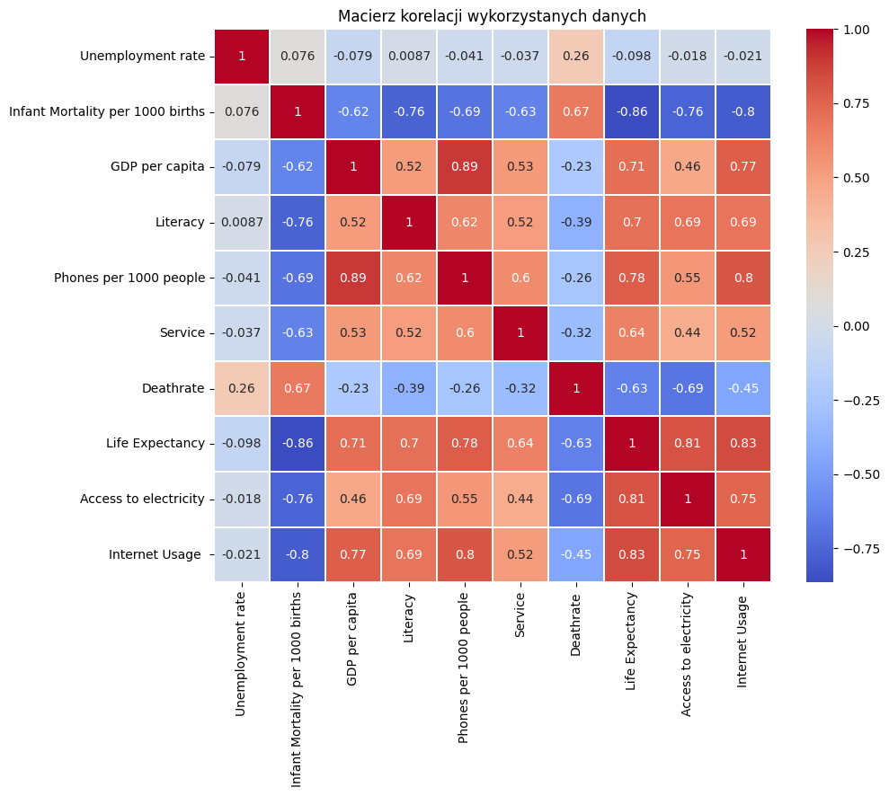

```python
import matplotlib.pyplot as plt
import seaborn as sns
import pandas as pd

df=data
correlation_matrix = df.drop(columns=['Countries']).corr()

plt.figure(figsize = (10, 8))
sns.heatmap(correlation_matrix, cmap="coolwarm", annot=True, linewidths=1.25, cbar=True).set(title='Macierz korelacji wykorzystanych danych')
plt.show()
```

## Badanie skośności

```python
from IPython.display import display
# Wybór interesujących kolumn (bez kolumny 'Countries')
wybrane_kolumny = data.drop(columns=['Countries'])

# Obliczanie współczynnika skośności dla wybranych kolumn
skewness = wybrane_kolumny.skew()

wyniki = pd.DataFrame(skewness, columns=['Współczynnik skośności'])

display(wyniki)
```

|  | Współczynnik skośności |
| --- | --- |
| Unemployment rate | 1.402262 |
| Infant Mortality per 1000 births | 1.192935 |
| GDP per capita | 1.595253 |
| Literacy | -1.064815 |
| Phones per 1000 people | 1.015754 |
| Service | -0.551726 |
| Deathrate | 1.321652 |
| Life Expectancy | -0.485037 |
| Access to electricity | -1.376915 |
| Internet Usage | -0.163125 |

## Badanie kurtozy

```python
wybrane_kolumny = data.drop(columns=['Countries'])
kurtoza = wybrane_kolumny.kurtosis()
wyniki = pd.DataFrame(kurtoza, columns=['kurtoza'])
# Wyświetlenie wyników
display(wyniki)
```

|  | kurtoza |
| --- | --- |
| Unemployment rate | 1.672937 |
| Infant Mortality per 1000 births | 1.101340 |
| GDP per capita | 2.423834 |
| Literacy | -0.040354 |
| Phones per 1000 people | -0.128065 |
| Service | 0.030364 |
| Deathrate | 1.609797 |
| Life Expectancy | -0.488115 |
| Access to electricity | 0.413518 |
| Internet Usage | -1.205686 |

1. **Unemployment rate (Stopa bezrobocia)**: Wartość kurtozy wynosi 1.672937, co sugeruje, że rozkład może być bardziej spięty wokół średniej, co może wskazywać na silne skupienie się wartości wokół wartości średniej. Może to oznaczać, że większość krajów ma podobne stopy bezrobocia, ale istnieją kraje z ekstremalnie wysokimi stopami, które przesuwają rozkład w prawo.
2. **Infant Mortality per 1000 births (Zdolność niemowląt na 1000 urodzeń)**: Wartość kurtozy wynosi 1.101340, co sugeruje, że rozkład może być bardziej spięty wokół średniej, ale mniej niż w przypadku stopy bezrobocia. Może to wskazywać na mniej zróżnicowane wartości wskaźnika umieralności niemowląt.
3. **GDP per capita (PKB na mieszkańca)**: Wartość kurtozy wynosi 2.423834, co sugeruje, że rozkład jest silnie spięty wokół średniej. To może oznaczać, że większość krajów ma zbliżone wartości PKB na mieszkańca, ale istnieją kraje z ekstremalnie wysokimi PKB, które przesuwają rozkład w prawo.
4. **Literacy (Alfabetyzacja)**: Wartość kurtozy wynosi -0.040354, co sugeruje, że rozkład jest mniej spięty wokół średniej i bardziej równomierny. To może oznaczać, że wartości wskaźnika alfabetyzacji są rozłożone równomierniej wśród krajów.
5. **Phones per 1000 people (Telefony na 1000 osób)**: Wartość kurtozy wynosi -0.128065, co sugeruje, że rozkład jest mniej spięty wokół średniej i bardziej równomierny. Może to oznaczać, że liczba telefonów na 1000 osób jest rozłożona równomierniej wśród krajów.
6. **Service (Usługi)**: Wartość kurtozy wynosi 0.030364, co sugeruje, że rozkład jest mniej spięty wokół średniej i bardziej równomierny. To może oznaczać, że poziom usług jest rozłożony równomierniej wśród krajów.
7. **Deathrate (Wskaźnik umieralności)**: Wartość kurtozy wynosi 1.609797, co sugeruje, że rozkład może być bardziej spięty wokół średniej. Może to oznaczać, że większość krajów ma podobne wskaźniki umieralności, ale istnieją kraje z ekstremalnie wysokimi wskaźnikami, które przesuwają rozkład w prawo.
8. **Life Expectancy (Średnia długość życia)**: Wartość kurtozy wynosi -0.488115, co sugeruje, że rozkład jest mniej spięty wokół średniej i bardziej równomierny. Może to oznaczać, że średnia długość życia jest rozłożona równomierniej wśród krajów.
9. **Access to electricity (Dostęp do elektryczności)**: Wartość kurtozy wynosi 0.413518, co sugeruje, że rozkład może być bardziej spięty wokół średniej. Może to oznaczać, że większość krajów ma podobne poziomy dostępu do elektryczności, ale istnieją kraje z ekstremalnie wysokimi lub niskimi poziomami, które przesuwają rozkład w prawo lub lewo.
10. **Internet Usage (Użycie internetu)**: Wartość kurtozy wynosi -1.205686, co sugeruje, że rozkład jest mniej spięty wokół średniej i bardziej równomierny. Może to oznaczać, że korzystanie z internetu jest rozłożone równomierniej wśród krajów.

```python
from scipy.cluster.hierarchy import linkage, fcluster
from scipy.spatial.distance import squareform
import numpy as np
import pandas as pd

pd.set_option('display.max_colwidth', None)
df=data.copy()
df2=df.drop(columns=['Countries'])

# Oblicz macierz korelacji
correlation_matrix = df2.corr()

# Oblicz macierz odległości na podstawie macierzy korelacji
distance_matrix = squareform(1 - correlation_matrix)

# Użyj metody Hellwiga do grupowania hierarchicznego
clusters = linkage(distance_matrix, method='ward')

# Wybierz 5 najmniej zależnych kolumn
n_columns = 5
clusters_labels = fcluster(clusters, n_columns, criterion='maxclust')
selected_columns_indices = np.argsort(clusters_labels)[:n_columns]
selected_columns = df2.columns[selected_columns_indices]

selected_columns_df = pd.DataFrame({'5 najmniej zależnych kolumn': selected_columns})

display(selected_columns_df)
```

|  | 5 najmniej zależnych kolumn |
| --- | --- |
| 0 | Literacy |
| 1 | Life Expectancy |
| 2 | Access to electricity |
| 3 | Internet Usage |
| 4 | GDP per capita |

# Analiza danych odstających

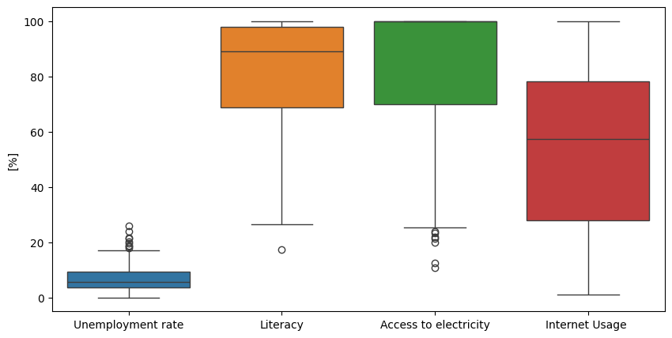

```python
import seaborn as sns
import matplotlib.pyplot as plt
plt.gcf().set_size_inches((10,5))
sns.boxplot(data=df.drop(columns=['GDP per capita','Infant Mortality per 1000 births','Phones per 1000 people','Service','Deathrate','Life Expectancy']))
plt.ylabel('[%]')
plt.show()
```

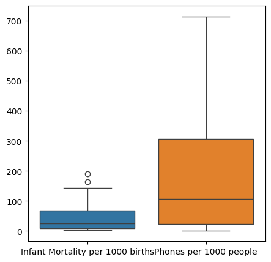

```python
import seaborn as sns
import matplotlib.pyplot as plt
plt.gcf().set_size_inches((5,5))
sns.boxplot(data=df.drop(columns=['GDP per capita','Service','Deathrate','Life Expectancy','Unemployment rate','Literacy','Access to electricity','Internet Usage ']))
plt.show()
```

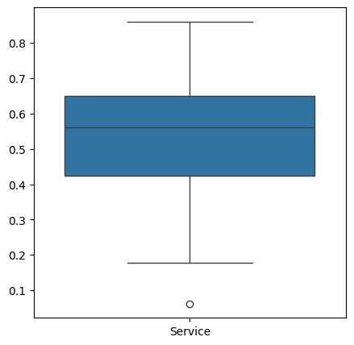

```python
import seaborn as sns
import matplotlib.pyplot as plt
plt.gcf().set_size_inches((5,5))
sns.boxplot(data=df.drop(columns=['Infant Mortality per 1000 births','Phones per 1000 people','Unemployment rate','Literacy','Access to electricity','Internet Usage ','GDP per capita','Life Expectancy','Deathrate']))
plt.show()
```

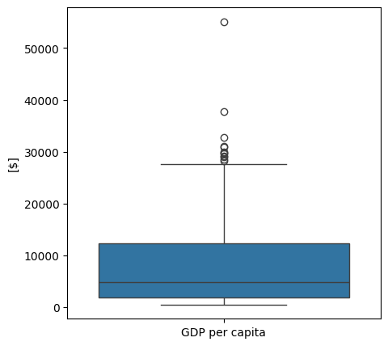

```python
import seaborn as sns
import matplotlib.pyplot as plt
plt.gcf().set_size_inches((5,5))
plt.ylabel('[$]')
sns.boxplot(data=df.drop(columns=['Infant Mortality per 1000 births','Phones per 1000 people','Unemployment rate','Literacy','Access to electricity','Internet Usage ','Service','Life Expectancy','Deathrate']))
plt.show()
```

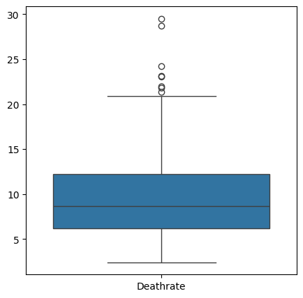

```python
import seaborn as sns
import matplotlib.pyplot as plt
plt.gcf().set_size_inches((5,5))
sns.boxplot(data=df.drop(columns=['Infant Mortality per 1000 births','Phones per 1000 people','Unemployment rate','Literacy','Access to electricity','Internet Usage ','GDP per capita','Life Expectancy','Service']))
plt.show()
```

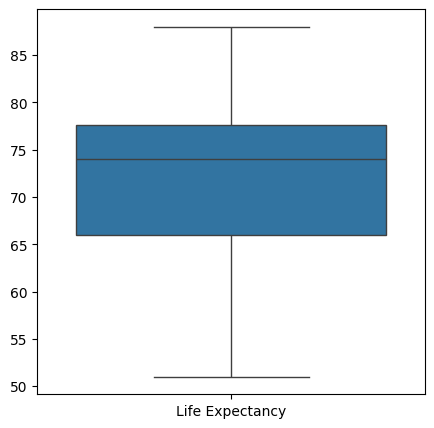

```python
import seaborn as sns
import matplotlib.pyplot as plt
plt.gcf().set_size_inches((5, 5))
sns.boxplot(data=df.drop(columns=['Infant Mortality per 1000 births','Phones per 1000 people','Unemployment rate','Literacy','Access to electricity','Internet Usage ','GDP per capita','Service','Deathrate']))
plt.show()
```

# Normalizacja danych i określenie stymulant i destymulant

```python
zmienne = df.columns.difference(['Countries'])
from sklearn.preprocessing import MinMaxScaler,StandardScaler

scaler = MinMaxScaler()
scaler.fit(df[zmienne])
df_normalized=pd.DataFrame(scaler.transform(df[zmienne]), columns=zmienne)

dane = pd.concat([df['Countries'],df_normalized],axis=1)
dane['Infant Mortality per 1000 births'] = dane['Infant Mortality per 1000 births'].apply(lambda x: -x)
dane['Deathrate'] = dane['Deathrate'].apply(lambda x: -x)
dane['Unemployment rate'] = dane['Unemployment rate'].apply(lambda x: -x)
display(df_normalized)
```

|  | Access to electricity | Deathrate | GDP per capita | Infant Mortality per 1000 births | Internet Usage | Life Expectancy | Literacy | Phones per 1000 people | Service | Unemployment rate |
| --- | --- | --- | --- | --- | --- | --- | --- | --- | --- | --- |
| 0 | 0.974186 | 0.661868 | 0.003663 | 0.851138 | 0.123607 | 0.378378 | 0.223301 | 0.002662 | 0.398496 | 0.425926 |
| 1 | 1.000000 | 0.103728 | 0.073260 | 0.101800 | 0.714286 | 0.724324 | 0.836165 | 0.097940 | 0.647870 | 0.520062 |
| 2 | 1.000000 | 0.081211 | 0.100733 | 0.151985 | 0.470111 | 0.664865 | 0.635922 | 0.107608 | 0.295739 | 0.457562 |
| 3 | 0.347924 | 0.804356 | 0.025641 | 1.000000 | 0.131712 | 0.037838 | 0.296117 | 0.009107 | 0.230576 | 0.636535 |
| 4 | 1.000000 | 0.189738 | 0.195971 | 0.068237 | 0.739615 | 0.683784 | 0.964806 | 0.306992 | 0.607769 | 0.316744 |
| ... | ... | ... | ... | ... | ... | ... | ... | ... | ... | ... |
| 128 | 1.000000 | 0.245109 | 0.225275 | 0.051138 | 0.678825 | 0.702703 | 0.975728 | 0.406473 | 0.669173 | 0.298997 |
| 129 | 1.000000 | 0.200443 | 0.021978 | 0.364267 | 0.516717 | 0.497297 | 0.991505 | 0.086311 | 0.461153 | 0.219522 |
| 130 | 0.582492 | 0.199705 | 0.043956 | 0.279884 | 0.247214 | 0.567568 | 0.429612 | 0.043856 | 0.699248 | 0.198380 |
| 131 | 0.329966 | 0.646733 | 0.005495 | 0.455267 | 0.269504 | 0.291892 | 0.764563 | 0.009668 | 0.535088 | 0.323302 |
| 132 | 0.331089 | 0.717239 | 0.025641 | 0.346215 | 0.261398 | 0.432432 | 0.887136 | 0.035729 | 0.647870 | 0.239545 |

133 rows × 10 columns

# Metoda TOPSIS

Metoda TOPSIS (Technique for Order of Preference by Similarity to Ideal Solution) to technika wielokryterialnej analizy decyzyjnej, która służy do wyboru najlepszego rozwiązania spośród dostępnych alternatyw. Została po raz pierwszy zaproponowana przez **Hwanga** i **Yoona** w 1981 roku w ich pracy "*Multiple Attribute Decision Making: An Introduction*".

Przykładem zastosowania metody **TOPSIS** w literaturze naukowej jest w pracy "*Multiple Attribute Decision Making: Methods and Applications*" autorstwa **Gwo-Hshiung Tzeng** i **Jih-Jeng Huang**, opublikowanej w 2011 roku. Cytat str 69:

> The Technique for Order Preferences by Similarity to an Ideal Solution (TOPSIS) method was proposed by Hwang and Yoon (1981). The main idea came from the concept of the compromise solution to choose the best alternative nearest to the positive ideal solution (optimal solution) and farthest from the negative ideal solution (inferior solution). Then, choose the best one of sorting, which will be the best alternative.

Metoda **TOPSIS** została zastosowana do porządkowania alternatyw w sytuacjach, gdzie istnieje wiele kryteriów oceny, a decydent musi wybrać najlepszą możliwą opcję. Może to obejmować decyzje dotyczące wyboru lokalizacji, wyboru produktów, oceny projektów inwestycyjnych itp. Metoda ta pomaga porównać alternatywy, biorąc pod uwagę zarówno ich odległość od idealnej opcji (maksymalizującej korzyści) jak i minimalizującej (minimalizującej koszty), co umożliwia wybór optymalnej decyzji.

Poniżej przedstawiono kroki tej metody:

#### Krok 1: Normalizacja macierzy decyzyjnej

- Niech $x_{ij}$ będzie wartością $( i )$-tej alternatywy dla $( j )$-tego kryterium w macierzy decyzyjnej $( X )$, gdzie $( i = 1, 2, ..., m )$ oraz $( j = 1, 2, ..., n )$.
- Znormalizuj macierz decyzyjną, dzieląc każdą wartość przez pierwiastek sumy kwadratów wartości w kolumnie:

#### Krok 2: Waga kryteriów

- Przypisz wagi $( w_j )$ każdemu kryterium, gdzie $( w_j )$ jest wagą $( j )$ -tego kryterium, spełniającą warunek:

  $ \sum_{j=1}^{n} w_j = 1 $

#### Krok 3: Macierz ważonych normalizowanych wartości

- Przemnóż znormalizowane wartości przez odpowiadające im wagi, tworząc macierz ważonych normalizowanych wartości ( Z ):

  $ z_{ij} = w_j \times x_{ij}^* $

#### Krok 4: Idealne i antyidealne rozwiązania

- Znajdź idealne $( A^+ )$ i antyidealne $( A^- )$ rozwiązania, które odpowiadają najlepszemu i najgorszemu stanowi dla każdego kryterium:

  $ A^+ = \left( \max(z_{1j}), \max(z_{2j}), ..., \max(z_{mj}) \right) $ $ A^- = \left( \min(z_{1j}), \min(z_{2j}), ..., \min(z_{mj}) \right) $

#### Krok 5: Odległość od idealnego i antyidealnego rozwiązania

- Oblicz odległość każdej alternatywy od idealnego $( d^+ )$ i antyidealnego $( d^- )$ rozwiązania, wykorzystując odległość euklidesową:

  $ d_i^+ = \sqrt{\sum_{j=1}^{n} (z_{ij} - A_j^+)^2} $ $ d_i^- = \sqrt{\sum_{j=1}^{n} (z_{ij} - A_j^-)^2} $

#### Krok 6: Bliskość do idealnego rozwiązania

- Oblicz bliskość każdej alternatywy do idealnego rozwiązania $( C_i )$ jako stosunek odległości od antyidealnego do sumy odległości od idealnego i antyidealnego:

  $ C_i = \frac{d_i^-}{d_i^+ + d_i^-} $

#### Krok 7: Rangowanie

- Ranguj alternatywy według wartości bliskości $( C_i )$, gdzie większa wartość $( C_i )$ oznacza lepsze rozwiązanie.

```python
import pandas as pd
import matplotlib.pyplot as plt
import numpy as np

from sklearn.preprocessing import MinMaxScaler,StandardScaler
df = pd.read_csv('projektdane2.csv')
wagi = [0.1,0.1,0.1,0.1,0.1,0.1,0.1,0.1,0.1,0.1]
zmienne= df.columns.difference(['Countries'])
scaler=MinMaxScaler()
scaler.fit(df[zmienne])
df_normalized=pd.DataFrame(scaler.transform(df[zmienne]), columns=zmienne)

dane= pd.concat([df['Countries'],df_normalized],axis=1)
dane['Infant Mortality per 1000 births']=dane['Infant Mortality per 1000 births'].apply(lambda x: -x)
dane['Deathrate']=dane['Deathrate'].apply(lambda x: -x)
dane['Unemployment rate']=dane['Unemployment rate'].apply(lambda x: -x)
def topsis(normalized_data, weights):
    """
    Funkcja wykonująca analizę TOPSIS na podstawie danych znormalizowanych.

    Parametry:
    - normalized_data: DataFrame lub tablica NumPy zawierająca dane znormalizowane
    - weights: tablica NumPy zawierająca wagi dla każdego kryterium

    Zwraca:
    - scores: tablica NumPy zawierająca wyniki TOPSIS dla każdej alternatywy
    """

    # Wartości optymalne i negatywne
    ideal_best = np.max(normalized_data, axis=0)
    ideal_worst = np.min(normalized_data, axis=0)

    # Odległości do wartości optymalnych
    dist_best = np.sqrt(np.sum((normalized_data*weights - ideal_best*weights) ** 2, axis=1))
    dist_worst = np.sqrt(np.sum((normalized_data*weights - ideal_worst*weights) ** 2, axis=1))

    # Wartości TOPSIS
    scores = dist_worst / (dist_worst + dist_best)

    return scores
dane['Wyniki TOPSIS'] = topsis(dane.iloc[:, 1:], wagi)
dane_sorted = dane.sort_values(by='Wyniki TOPSIS', ascending=False)
pd.set_option('display.max_rows', None)
pd.set_option('display.max_columns', None)
dane_sorted['Topsis'] = np.arange(1, len(dane_sorted) + 1)
display(dane_sorted)
topsis_df = dane_sorted[['Countries', 'Topsis']].copy()
```

|  | Countries | Access to electricity | Deathrate | GDP per capita | Infant Mortality per 1000 births | Internet Usage | Life Expectancy | Literacy | Phones per 1000 people | Service | Unemployment rate | Wyniki TOPSIS | Topsis |
| --- | --- | --- | --- | --- | --- | --- | --- | --- | --- | --- | --- | --- | --- |
| 72 | Luxembourg | 1.000000 | -0.221484 | 1.000000 | -0.013340 | 0.973658 | 0.837838 | 1.000000 | 0.720331 | 1.000000 | -0.207562 | 0.866882 | 1 |
| 54 | Iceland | 1.000000 | -0.159099 | 0.556777 | -0.005400 | 0.982776 | 0.856757 | 0.998786 | 0.905703 | 0.880952 | -0.100309 | 0.844315 | 2 |
| 117 | Switzerland | 1.000000 | -0.224437 | 0.589744 | -0.011117 | 0.895643 | 0.875676 | 0.987864 | 0.952221 | 0.730576 | -0.179784 | 0.822659 | 3 |
| 31 | Denmark | 1.000000 | -0.293466 | 0.560440 | -0.012017 | 0.970618 | 0.945946 | 1.000000 | 0.859325 | 0.843358 | -0.219522 | 0.818916 | 4 |
| 6 | Australia | 1.000000 | -0.188261 | 0.521978 | -0.012705 | 0.863222 | 0.859459 | 1.000000 | 0.790528 | 0.799499 | -0.210262 | 0.804302 | 5 |
| 23 | Canada | 1.000000 | -0.198966 | 0.536630 | -0.013023 | 0.908815 | 0.843243 | 0.963592 | 0.771893 | 0.779449 | -0.242670 | 0.799712 | 6 |
| 116 | Sweden | 1.000000 | -0.291621 | 0.481685 | -0.002541 | 0.954407 | 0.848649 | 0.987864 | 1.000000 | 0.808271 | -0.253858 | 0.798579 | 7 |
| 44 | Germany | 1.000000 | -0.303064 | 0.496337 | -0.009899 | 0.841945 | 0.810811 | 0.987864 | 0.934006 | 0.793233 | -0.139275 | 0.797058 | 8 |
| 92 | Norway | 1.000000 | -0.258029 | 0.683150 | -0.007464 | 0.963526 | 0.832432 | 1.000000 | 0.645089 | 0.629073 | -0.155093 | 0.793525 | 9 |
| 87 | Netherlands | 1.000000 | -0.231451 | 0.514652 | -0.014558 | 0.931104 | 0.835135 | 0.987864 | 0.643828 | 0.844612 | -0.181327 | 0.790162 | 10 |
| 62 | Japan | 1.000000 | -0.249169 | 0.507326 | -0.005135 | 0.843972 | 0.883784 | 0.987864 | 0.644388 | 0.830827 | -0.103395 | 0.789905 | 11 |
| 41 | France | 1.000000 | -0.248431 | 0.496337 | -0.010429 | 0.802432 | 0.848649 | 0.987864 | 0.819812 | 0.879699 | -0.357639 | 0.780551 | 12 |
| 7 | Austria | 1.000000 | -0.271318 | 0.540293 | -0.012546 | 0.877406 | 0.824324 | 0.975728 | 0.631778 | 0.771930 | -0.209105 | 0.776822 | 13 |
| 13 | Belgium | 1.000000 | -0.290144 | 0.523810 | -0.012652 | 0.875380 | 0.813514 | 0.975728 | 0.646350 | 0.860902 | -0.268133 | 0.774575 | 14 |
| 108 | Singapore | 1.000000 | -0.069029 | 0.424908 | -0.000000 | 0.841945 | 0.867568 | 0.908981 | 0.574611 | 0.750627 | -0.156636 | 0.765125 | 15 |
| 88 | New Zealand | 1.000000 | -0.189000 | 0.386447 | -0.018846 | 0.906788 | 0.827027 | 0.987864 | 0.617066 | 0.779449 | -0.177469 | 0.761557 | 16 |
| 58 | Ireland | 1.000000 | -0.199705 | 0.532967 | -0.016411 | 0.838906 | 0.821622 | 0.975728 | 0.699454 | 0.536341 | -0.253472 | 0.755575 | 17 |
| 59 | Israel | 1.000000 | -0.139166 | 0.353480 | -0.025093 | 0.813576 | 0.851351 | 0.944175 | 0.645930 | 0.745614 | -0.154321 | 0.755313 | 18 |
| 78 | Malta | 1.000000 | -0.210041 | 0.315018 | -0.008470 | 0.807497 | 0.829730 | 0.912621 | 0.705759 | 0.849624 | -0.148920 | 0.755019 | 19 |
| 40 | Finland | 1.000000 | -0.275009 | 0.492674 | -0.006776 | 0.873354 | 0.813514 | 1.000000 | 0.566064 | 0.769424 | -0.327932 | 0.749252 | 20 |
| 109 | Slovenia | 1.000000 | -0.291621 | 0.338828 | -0.011435 | 0.786221 | 1.000000 | 0.996359 | 0.567185 | 0.677945 | -0.248071 | 0.727345 | 21 |
| 60 | Italy | 1.000000 | -0.294943 | 0.479853 | -0.019322 | 0.626140 | 0.856757 | 0.983010 | 0.601934 | 0.784461 | -0.427083 | 0.721633 | 22 |
| 11 | Barbados | 1.000000 | -0.231082 | 0.278388 | -0.054050 | 0.815603 | 0.662162 | 0.968447 | 0.673392 | 0.899749 | -0.327160 | 0.720634 | 23 |
| 127 | United Arab Emirates | 1.000000 | -0.073459 | 0.415751 | -0.064690 | 0.947315 | 0.705405 | 0.731796 | 0.664145 | 0.392231 | -0.089506 | 0.714192 | 24 |
| 9 | Bahrain | 1.000000 | -0.063861 | 0.300366 | -0.079301 | 0.958460 | 0.700000 | 0.867718 | 0.392322 | 0.684211 | -0.040586 | 0.710736 | 25 |
| 100 | Portugal | 1.000000 | -0.298634 | 0.320513 | -0.014611 | 0.734549 | 0.813514 | 0.918689 | 0.557517 | 0.765664 | -0.336806 | 0.706439 | 26 |
| 112 | Spain | 1.000000 | -0.269841 | 0.393773 | -0.011276 | 0.843972 | 0.859459 | 0.974515 | 0.633600 | 0.755639 | -0.658951 | 0.701604 | 27 |
| 66 | Kuwait | 1.000000 | -0.000000 | 0.338828 | -0.040551 | 1.000000 | 0.640541 | 0.799757 | 0.293821 | 0.568922 | -0.079630 | 0.688441 | 28 |
| 38 | Estonia | 1.000000 | -0.400148 | 0.216117 | -0.029539 | 0.879433 | 0.718919 | 0.997573 | 0.465882 | 0.756892 | -0.216821 | 0.686378 | 29 |
| 53 | Hungary | 1.000000 | -0.394980 | 0.245421 | -0.033245 | 0.764944 | 0.670270 | 0.992718 | 0.469245 | 0.738095 | -0.155093 | 0.682775 | 30 |

[output cut: 103 more lines]

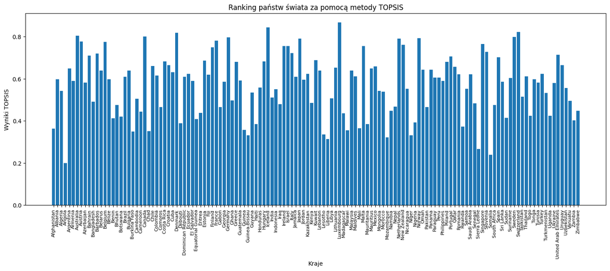

```python
import pandas as pd
import matplotlib.pyplot as plt

x_dane = dane['Countries']
y_dane = dane['Wyniki TOPSIS']

fig = plt.figure(figsize=(18, 6))
ax = plt.axes()
plt.bar(x_dane, y_dane, align='center')

plt.xlabel('Kraje')
plt.ylabel('Wyniki TOPSIS')
plt.title('Ranking państw świata za pomocą metody TOPSIS')
plt.xticks(rotation='vertical')
ax.tick_params(axis='x', labelsize=8)
plt.show()
```

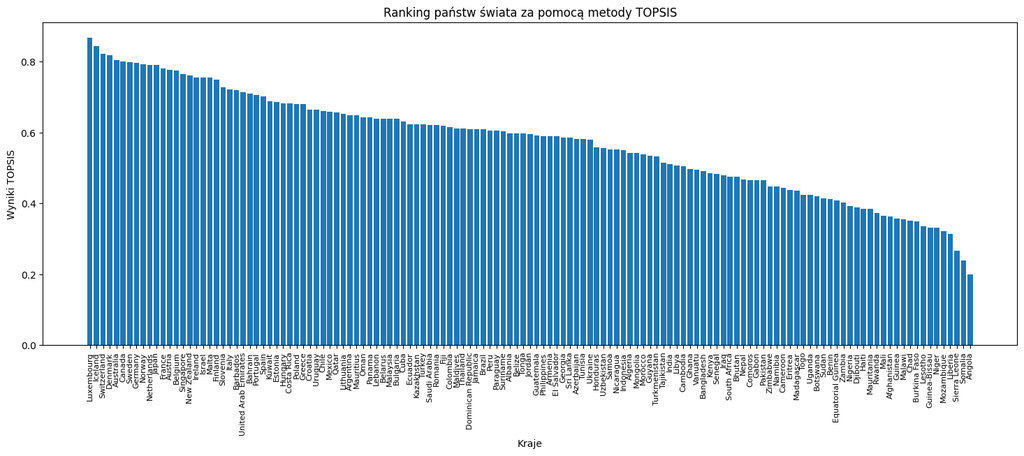

```python
import pandas as pd
import matplotlib.pyplot as plt

x_dane = dane_sorted['Countries']
y_dane = dane_sorted['Wyniki TOPSIS']

fig = plt.figure(figsize=(18, 6))
ax = plt.axes()
plt.bar(x_dane, y_dane, align='center')

plt.xlabel('Kraje')
plt.ylabel('Wyniki TOPSIS')
plt.title('Ranking państw świata za pomocą metody TOPSIS')
plt.xticks(rotation='vertical')
ax.tick_params(axis='x', labelsize=8)
plt.show()
```

# Metoda MUZ

Metoda MUZ to technika wielokryterialnej analizy decyzyjnej, która służy do wyboru najlepszego rozwiązania spośród dostępnych alternatyw.

Aby obliczyć wartość dla jednego wiersza metodą MUZ należy najpierw znormalizować dane za pomocą tak zwanej metody normalizacji min-max potem dodać wszystkie cechy i na końcu podzielić przez liczbe kolumn.

$$ wynik_j = \frac{1}{n}\sum_{i=1}^{n} \frac{x_{ij} - \text{min}_i}{\text{max}_i - \text{min}_i} $$ gdzie:

$i$ - oznacza numer kolumny (cechy)

$j$ - oznacza numer wiersza

$n$ - oznacza liczbę cech

$x_{ij}$ - oznacza konkretną wartość dla konkretnej cechy

$min_i$ - oznacza minimalną wartość dla danej cechy

$max_i$ - oznacza maksymalną wartość dla danej cechy

Na koniec należy posortować listę gdzie większa wartość MUZ oznacza lepsze rozwiązanie.

```python
import pandas as pd
import matplotlib.pyplot as plt

dane = pd.read_csv('projektdane2.csv')
wyniki_MUZ = []

dane['Infant Mortality per 1000 births']=dane['Infant Mortality per 1000 births'].apply(lambda x: -x)
dane['Deathrate']=dane['Deathrate'].apply(lambda x: -x)
dane['Unemployment rate']=dane['Unemployment rate'].apply(lambda x: -x)

for i in range(len(dane)):
  temp = 0
  for column in dane:
    if column != 'Countries':
      temp += (dane[column][i]-min(dane[column]))/(max(dane[column])-min(dane[column]))
  temp /= len(dane.columns) - 1
  wyniki_MUZ.append(temp)
dane['Wyniki MUZ']=wyniki_MUZ
dane['Infant Mortality per 1000 births']=dane['Infant Mortality per 1000 births'].apply(lambda x: -x)
dane['Deathrate']=dane['Deathrate'].apply(lambda x: -x)
dane['Unemployment rate']=dane['Unemployment rate'].apply(lambda x: -x)
dane_sorted = dane.sort_values(by='Wyniki MUZ', ascending=False)
pd.set_option('display.max_rows', None)  # Wyświetl wszystkie wiersze
pd.set_option('display.max_columns', None)  # Wyświetl wszystkie kolumny
dane_sorted['MUZ'] = np.arange(1, len(dane_sorted) + 1)
display(dane_sorted)
muz_df = dane_sorted[['Countries', 'MUZ']].copy()
```

|  | Countries | Unemployment rate | Infant Mortality per 1000 births | GDP per capita | Literacy | Phones per 1000 people | Service | Deathrate | Life Expectancy | Access to electricity | Internet Usage | Wyniki MUZ | MUZ |
| --- | --- | --- | --- | --- | --- | --- | --- | --- | --- | --- | --- | --- | --- |
| 72 | Luxembourg | 5.520 | 4.81 | 55100 | 100.0 | 515.4 | 0.860 | 8.41 | 82.0 | 100.0 | 97.4 | 0.908944 | 1 |
| 54 | Iceland | 2.740 | 3.31 | 30900 | 99.9 | 647.7 | 0.765 | 6.72 | 82.7 | 100.0 | 98.3 | 0.891694 | 2 |
| 31 | Denmark | 5.830 | 4.56 | 31100 | 100.0 | 614.6 | 0.735 | 10.36 | 86.0 | 100.0 | 97.1 | 0.865468 | 3 |
| 117 | Switzerland | 4.800 | 4.39 | 32700 | 99.0 | 680.9 | 0.645 | 8.49 | 83.4 | 100.0 | 89.7 | 0.861639 | 4 |
| 116 | Sweden | 6.720 | 2.77 | 26800 | 99.0 | 715.0 | 0.707 | 10.31 | 82.4 | 100.0 | 95.5 | 0.853286 | 5 |
| 6 | Australia | 5.590 | 4.69 | 29000 | 100.0 | 565.5 | 0.700 | 7.51 | 82.8 | 100.0 | 86.5 | 0.842346 | 6 |
| 44 | Germany | 3.750 | 4.16 | 27600 | 99.0 | 667.9 | 0.695 | 10.62 | 81.0 | 100.0 | 84.4 | 0.841196 | 7 |
| 23 | Canada | 6.430 | 4.75 | 29800 | 97.0 | 552.2 | 0.684 | 7.80 | 82.2 | 100.0 | 91.0 | 0.834896 | 8 |
| 62 | Japan | 2.820 | 3.26 | 28200 | 99.0 | 461.2 | 0.725 | 9.16 | 83.7 | 100.0 | 84.6 | 0.834046 | 9 |
| 92 | Norway | 4.160 | 3.70 | 37800 | 100.0 | 461.7 | 0.564 | 9.40 | 81.8 | 100.0 | 96.4 | 0.833268 | 10 |
| 87 | Netherlands | 4.840 | 5.04 | 28600 | 99.0 | 460.8 | 0.736 | 8.68 | 81.9 | 100.0 | 93.2 | 0.832986 | 11 |
| 41 | France | 9.410 | 4.26 | 27600 | 99.0 | 586.4 | 0.764 | 9.14 | 82.4 | 100.0 | 80.5 | 0.821829 | 12 |
| 108 | Singapore | 4.200 | 2.29 | 23700 | 92.5 | 411.4 | 0.661 | 4.28 | 83.1 | 100.0 | 84.4 | 0.814297 | 13 |
| 7 | Austria | 5.560 | 4.66 | 30000 | 98.0 | 452.2 | 0.678 | 9.76 | 81.5 | 100.0 | 87.9 | 0.812849 | 14 |
| 13 | Belgium | 7.090 | 4.68 | 29100 | 98.0 | 462.6 | 0.749 | 10.27 | 81.1 | 100.0 | 87.7 | 0.812475 | 15 |
| 88 | New Zealand | 4.740 | 5.85 | 21600 | 99.0 | 441.7 | 0.684 | 7.53 | 81.6 | 100.0 | 90.8 | 0.811933 | 16 |
| 78 | Malta | 4.000 | 3.89 | 17700 | 92.8 | 505.0 | 0.740 | 8.10 | 81.7 | 100.0 | 81.0 | 0.805282 | 17 |
| 59 | Israel | 4.140 | 7.03 | 19800 | 95.4 | 462.3 | 0.657 | 6.18 | 82.5 | 100.0 | 81.6 | 0.803555 | 18 |
| 58 | Ireland | 6.710 | 5.39 | 29600 | 98.0 | 500.5 | 0.490 | 7.82 | 81.4 | 100.0 | 84.1 | 0.793543 | 19 |
| 40 | Finland | 8.640 | 3.57 | 27400 | 100.0 | 405.3 | 0.676 | 9.86 | 81.1 | 100.0 | 87.5 | 0.790531 | 20 |
| 109 | Slovenia | 6.570 | 4.45 | 19000 | 99.7 | 406.1 | 0.603 | 10.31 | 88.0 | 100.0 | 78.9 | 0.781541 | 21 |
| 9 | Bahrain | 1.192 | 17.27 | 16900 | 89.1 | 281.3 | 0.608 | 4.14 | 76.9 | 100.0 | 95.9 | 0.771933 | 22 |
| 11 | Barbados | 8.620 | 12.50 | 15700 | 97.4 | 481.9 | 0.780 | 8.67 | 75.5 | 100.0 | 81.8 | 0.768545 | 23 |
| 127 | United Arab Emirates | 2.460 | 14.51 | 23200 | 77.9 | 475.3 | 0.375 | 4.40 | 77.1 | 100.0 | 94.8 | 0.762899 | 24 |
| 60 | Italy | 11.210 | 5.94 | 26700 | 98.6 | 430.9 | 0.688 | 10.40 | 82.7 | 100.0 | 63.1 | 0.759081 | 25 |
| 66 | Kuwait | 2.204 | 9.95 | 19000 | 83.5 | 211.0 | 0.516 | 2.41 | 74.7 | 100.0 | 100.0 | 0.752169 | 26 |
| 112 | Spain | 17.220 | 4.42 | 22000 | 97.9 | 453.5 | 0.665 | 9.72 | 82.8 | 100.0 | 84.6 | 0.752089 | 27 |
| 100 | Portugal | 8.870 | 5.05 | 18000 | 93.3 | 399.2 | 0.673 | 10.50 | 81.1 | 100.0 | 73.8 | 0.746040 | 28 |
| 38 | Estonia | 5.760 | 7.87 | 12300 | 99.8 | 333.8 | 0.666 | 13.25 | 77.6 | 100.0 | 88.1 | 0.738831 | 29 |
| 46 | Greece | 21.410 | 5.53 | 20000 | 97.5 | 589.7 | 0.733 | 10.24 | 81.0 | 100.0 | 70.5 | 0.737723 | 30 |

[output cut: 103 more lines]

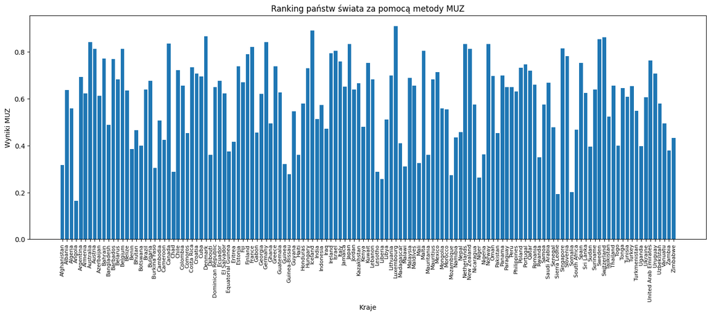

```python
import pandas as pd
import matplotlib.pyplot as plt

x_dane = dane['Countries']
y_dane = dane['Wyniki MUZ']

fig = plt.figure(figsize=(18, 6))
ax = plt.axes()
plt.bar(x_dane, y_dane, align='center')

plt.xlabel('Kraje')
plt.ylabel('Wyniki MUZ')
plt.title('Ranking państw świata za pomocą metody MUZ')
plt.xticks(rotation='vertical')
ax.tick_params(axis='x', labelsize=8)
plt.show()
```

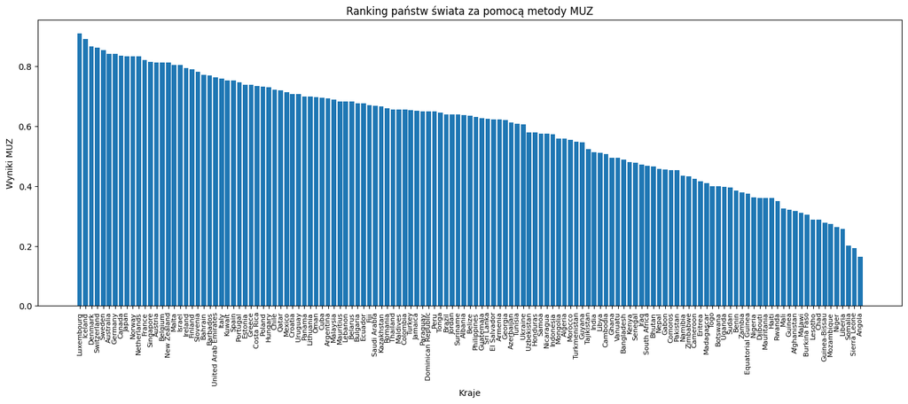

```python
import pandas as pd
import matplotlib.pyplot as plt

x_dane = dane_sorted['Countries']
y_dane = dane_sorted['Wyniki MUZ']

fig = plt.figure(figsize=(18, 6))
ax = plt.axes()
plt.bar(x_dane, y_dane, align='center')

plt.xlabel('Kraje')
plt.ylabel('Wyniki MUZ')
plt.title('Ranking państw świata za pomocą metody MUZ')
plt.xticks(rotation='vertical')
ax.tick_params(axis='x', labelsize=8)
plt.show()
```

# Metoda SSW

Metoda porządkowania liniowego SSW jest techniką standaryzacji danych w celu ich porządkowania. Jest to operacja wykonywana w statystyce, często używana przed analizą danych w celu porównywania różnych cech lub obserwacji. $$ wynik_i = \frac{1}{m}\sum_{i=1}^{m} Q_i = \frac 1 m \sum_{i=1}^{m}\frac{X_{ij} - 𝑋̄_j}{S_j} $$

Objaśnienia:

$Q_i$ - Wartość cechy syntetycznej dla i-tego obiektu

$m$ - Liczba cech

$X_{ij}$ - Wartość j-tej cechy dla i-tego obiektu

$𝑋̄_j$ - Średnia arytmetyczna wartości j-tej cechy we wszystkich obiektach

$S_j$ - Odchylenie standardowe wartości j-tej cechy we wszystkich obiektach

```python
import pandas as pd
import matplotlib.pyplot as plt

dane = pd.read_csv('projektdane2.csv')
wyniki_SSW = []

dane['Infant Mortality per 1000 births']=dane['Infant Mortality per 1000 births'].apply(lambda x: -x)
dane['Deathrate']=dane['Deathrate'].apply(lambda x: -x)
dane['Unemployment rate']=dane['Unemployment rate'].apply(lambda x: -x)

for i in range(len(dane)):
    Qi = 0
    for column in dane:
        if column != 'Countries':
            # Obliczenie średniej dla danej kolumny
            mean_value = dane[column].mean()
            # Obliczenie odchylenia standardowego dla danej kolumny
            std_deviation = dane[column].std()
            Qi += (dane[column][i] - mean_value) / std_deviation
    Qi /= len(dane.columns) - 1
    wyniki_SSW.append(Qi)

dane['Wyniki SSW']=wyniki_SSW
dane['Infant Mortality per 1000 births']=dane['Infant Mortality per 1000 births'].apply(lambda x: -x)
dane['Deathrate']=dane['Deathrate'].apply(lambda x: -x)
dane['Unemployment rate']=dane['Unemployment rate'].apply(lambda x: -x)
dane_sorted = dane.sort_values(by='Wyniki SSW', ascending=False)
pd.set_option('display.max_rows', None)  # Wyświetl wszystkie wiersze
pd.set_option('display.max_columns', None)  # Wyświetl wszystkie kolumny
dane_sorted['SSW'] = np.arange(1, len(dane_sorted) + 1)
display(dane_sorted)
ssw_df = dane_sorted[['Countries', 'SSW']].copy()
```

|  | Countries | Unemployment rate | Infant Mortality per 1000 births | GDP per capita | Literacy | Phones per 1000 people | Service | Deathrate | Life Expectancy | Access to electricity | Internet Usage | Wyniki SSW | SSW |
| --- | --- | --- | --- | --- | --- | --- | --- | --- | --- | --- | --- | --- | --- |
| 72 | Luxembourg | 5.520 | 4.81 | 55100 | 100.0 | 515.4 | 0.860 | 8.41 | 82.0 | 100.0 | 97.4 | 1.424907 | 1 |
| 54 | Iceland | 2.740 | 3.31 | 30900 | 99.9 | 647.7 | 0.765 | 6.72 | 82.7 | 100.0 | 98.3 | 1.293214 | 2 |
| 31 | Denmark | 5.830 | 4.56 | 31100 | 100.0 | 614.6 | 0.735 | 10.36 | 86.0 | 100.0 | 97.1 | 1.164935 | 3 |
| 117 | Switzerland | 4.800 | 4.39 | 32700 | 99.0 | 680.9 | 0.645 | 8.49 | 83.4 | 100.0 | 89.7 | 1.146206 | 4 |
| 116 | Sweden | 6.720 | 2.77 | 26800 | 99.0 | 715.0 | 0.707 | 10.31 | 82.4 | 100.0 | 95.5 | 1.091127 | 5 |
| 6 | Australia | 5.590 | 4.69 | 29000 | 100.0 | 565.5 | 0.700 | 7.51 | 82.8 | 100.0 | 86.5 | 1.076171 | 6 |
| 44 | Germany | 3.750 | 4.16 | 27600 | 99.0 | 667.9 | 0.695 | 10.62 | 81.0 | 100.0 | 84.4 | 1.057395 | 7 |
| 62 | Japan | 2.820 | 3.26 | 28200 | 99.0 | 461.2 | 0.725 | 9.16 | 83.7 | 100.0 | 84.6 | 1.056640 | 8 |
| 87 | Netherlands | 4.840 | 5.04 | 28600 | 99.0 | 460.8 | 0.736 | 8.68 | 81.9 | 100.0 | 93.2 | 1.042631 | 9 |
| 23 | Canada | 6.430 | 4.75 | 29800 | 97.0 | 552.2 | 0.684 | 7.80 | 82.2 | 100.0 | 91.0 | 1.039487 | 10 |
| 92 | Norway | 4.160 | 3.70 | 37800 | 100.0 | 461.7 | 0.564 | 9.40 | 81.8 | 100.0 | 96.4 | 1.034563 | 11 |
| 41 | France | 9.410 | 4.26 | 27600 | 99.0 | 586.4 | 0.764 | 9.14 | 82.4 | 100.0 | 80.5 | 0.984199 | 12 |
| 108 | Singapore | 4.200 | 2.29 | 23700 | 92.5 | 411.4 | 0.661 | 4.28 | 83.1 | 100.0 | 84.4 | 0.971522 | 13 |
| 13 | Belgium | 7.090 | 4.68 | 29100 | 98.0 | 462.6 | 0.749 | 10.27 | 81.1 | 100.0 | 87.7 | 0.952249 | 14 |
| 7 | Austria | 5.560 | 4.66 | 30000 | 98.0 | 452.2 | 0.678 | 9.76 | 81.5 | 100.0 | 87.9 | 0.951806 | 15 |
| 88 | New Zealand | 4.740 | 5.85 | 21600 | 99.0 | 441.7 | 0.684 | 7.53 | 81.6 | 100.0 | 90.8 | 0.938689 | 16 |
| 78 | Malta | 4.000 | 3.89 | 17700 | 92.8 | 505.0 | 0.740 | 8.10 | 81.7 | 100.0 | 81.0 | 0.916832 | 17 |
| 59 | Israel | 4.140 | 7.03 | 19800 | 95.4 | 462.3 | 0.657 | 6.18 | 82.5 | 100.0 | 81.6 | 0.907963 | 18 |
| 40 | Finland | 8.640 | 3.57 | 27400 | 100.0 | 405.3 | 0.676 | 9.86 | 81.1 | 100.0 | 87.5 | 0.846708 | 19 |
| 58 | Ireland | 6.710 | 5.39 | 29600 | 98.0 | 500.5 | 0.490 | 7.82 | 81.4 | 100.0 | 84.1 | 0.843545 | 20 |
| 109 | Slovenia | 6.570 | 4.45 | 19000 | 99.7 | 406.1 | 0.603 | 10.31 | 88.0 | 100.0 | 78.9 | 0.796092 | 21 |
| 9 | Bahrain | 1.192 | 17.27 | 16900 | 89.1 | 281.3 | 0.608 | 4.14 | 76.9 | 100.0 | 95.9 | 0.774707 | 22 |
| 11 | Barbados | 8.620 | 12.50 | 15700 | 97.4 | 481.9 | 0.780 | 8.67 | 75.5 | 100.0 | 81.8 | 0.742496 | 23 |
| 60 | Italy | 11.210 | 5.94 | 26700 | 98.6 | 430.9 | 0.688 | 10.40 | 82.7 | 100.0 | 63.1 | 0.722288 | 24 |
| 127 | United Arab Emirates | 2.460 | 14.51 | 23200 | 77.9 | 475.3 | 0.375 | 4.40 | 77.1 | 100.0 | 94.8 | 0.702828 | 25 |
| 66 | Kuwait | 2.204 | 9.95 | 19000 | 83.5 | 211.0 | 0.516 | 2.41 | 74.7 | 100.0 | 100.0 | 0.689780 | 26 |
| 100 | Portugal | 8.870 | 5.05 | 18000 | 93.3 | 399.2 | 0.673 | 10.50 | 81.1 | 100.0 | 73.8 | 0.650066 | 27 |
| 112 | Spain | 17.220 | 4.42 | 22000 | 97.9 | 453.5 | 0.665 | 9.72 | 82.8 | 100.0 | 84.6 | 0.649448 | 28 |
| 28 | Costa Rica | 7.730 | 9.95 | 9100 | 96.0 | 340.7 | 0.614 | 4.36 | 79.6 | 99.6 | 71.4 | 0.600540 | 29 |
| 38 | Estonia | 5.760 | 7.87 | 12300 | 99.8 | 333.8 | 0.666 | 13.25 | 77.6 | 100.0 | 88.1 | 0.597179 | 30 |

[output cut: 103 more lines]

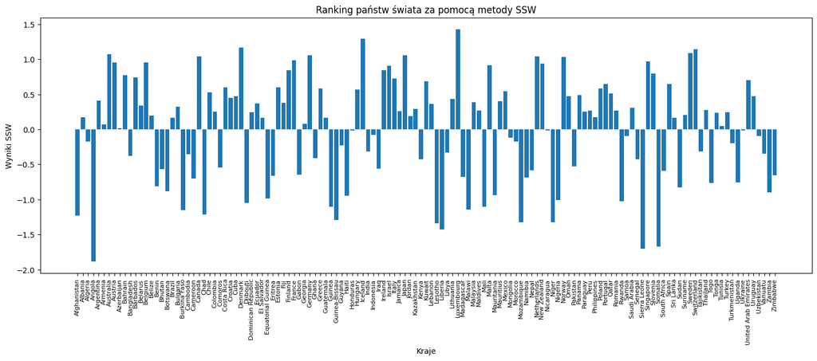

```python
import pandas as pd
import matplotlib.pyplot as plt

x_dane = dane['Countries']
y_dane = dane['Wyniki SSW']

fig = plt.figure(figsize=(18, 6))
ax = plt.axes()
plt.bar(x_dane, y_dane, align='center')

plt.xlabel('Kraje')
plt.ylabel('Wyniki SSW')
plt.title('Ranking państw świata za pomocą metody SSW')
plt.xticks(rotation='vertical')
ax.tick_params(axis='x', labelsize=8)
plt.show()
```

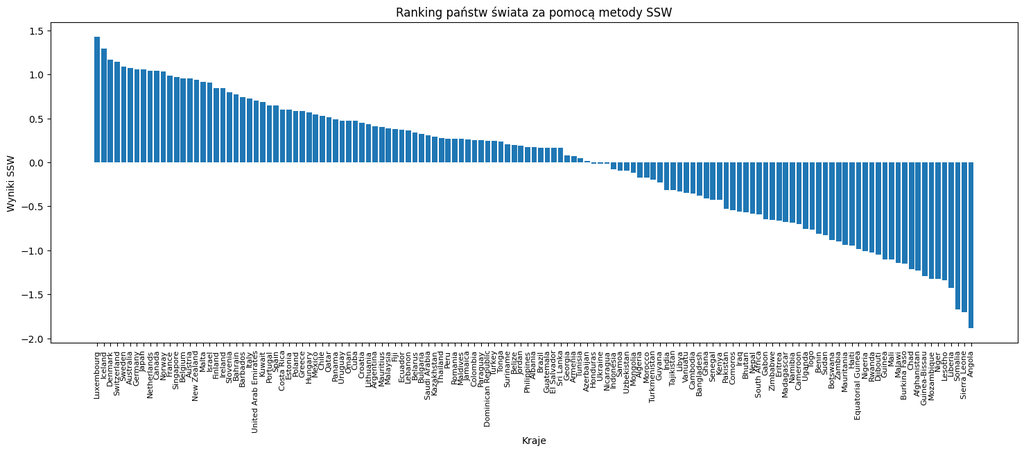

```python
import pandas as pd
import matplotlib.pyplot as plt

x_dane = dane_sorted['Countries']
y_dane = dane_sorted['Wyniki SSW']

fig = plt.figure(figsize=(18, 6))
ax = plt.axes()
plt.bar(x_dane, y_dane, align='center')

plt.xlabel('Kraje')
plt.ylabel('Wyniki SSW')
plt.xticks(rotation='vertical')
plt.title('Ranking państw świata za pomocą metody SSW')
ax.tick_params(axis='x', labelsize=8)
plt.show()
```

# Metoda Hellwiga

Metoda stworzona w 1968 roku przez Zdzisława Hellwiga. Zwana również metodą optymalnego wyboru predyktant, metodą wskaźników pojemności informacji.

Podobnie jak przy metodzie TOPSIS, poszczególne kroki do wykonania przy użyciu tej metody to

#### Normalizacja danych

$x_{ij}^* = \frac{x_{ij}-\bar{x}{_{ij}}}{S_j}$

Gdzie $S_j$ - odchylenie standardowe wartości cechy dla wszystkich rekordów

#### Obliczenie idealnego rozwiązania dla danej cechy oraz odległości od idealnego rozwiązania

$z_j^+ = max\{z_{ij}\}$

$d_i^+ = \sqrt{\sum_{j=1}^{m}(z_{ij}-z_j^+)^2}$

#### Obliczenie średniej odległości oraz odchylenia standardowego

$\bar{d} = \frac{\sum_{i=1}^{n}d_i^+}{n}$

#### Obliczenie bliskości od idealnego rozwiązania

$Q_i=1-\frac{d_i^+}{d_0}$

```python
import pandas as pd
import matplotlib.pyplot as plt
from math import sqrt

dane = pd.read_csv('projektdane2.csv')
wyniki_Hellwig = []

dane['Infant Mortality per 1000 births']=dane['Infant Mortality per 1000 births'].apply(lambda x: -x)
dane['Deathrate']=dane['Deathrate'].apply(lambda x: -x)
dane['Unemployment rate']=dane['Unemployment rate'].apply(lambda x: -x)


# Normalizacja
z = []
for i in range(len(dane)):
    row = []
    for column in dane:
        if column == "Countries":
            continue

        mean_value = dane[column].mean()
        std_deviation = dane[column].std()

        row.append((dane[column][i] - mean_value) / std_deviation)
    z.append(row)


d = []
for i in range(len(z)):
    d.append(0)
    for j in range(len(z[i])):
        z_max = max(kol[j] for kol in z)

        d[i] += (z[i][j] - z_max)**2

    d[i] = sqrt(d[i])

S_d = 0
d_fin = sum(d) / len(dane)
for i in range(len(dane)):
    S_d += (d[i] - d_fin)**2
S_d = sqrt(S_d) / len(dane)
d_0 = d_fin + 2 * S_d

for i in range(len(dane)):
    Qi = 1 - d[i] / d_0
    wyniki_Hellwig.append(Qi)

dane['Wyniki Hellwig']=wyniki_Hellwig
dane['Infant Mortality per 1000 births']=dane['Infant Mortality per 1000 births'].apply(lambda x: -x)
dane['Deathrate']=dane['Deathrate'].apply(lambda x: -x)
dane['Unemployment rate']=dane['Unemployment rate'].apply(lambda x: -x)
dane_sorted = dane.sort_values(by='Wyniki Hellwig', ascending=False)
pd.set_option('display.max_rows', None)
pd.set_option('display.max_columns', None)
dane_sorted['Hellwig'] = np.arange(1, len(dane_sorted) + 1)
display(dane_sorted)
hellwig_df = dane_sorted[['Countries', 'Hellwig']].copy()
```

|  | Countries | Unemployment rate | Infant Mortality per 1000 births | GDP per capita | Literacy | Phones per 1000 people | Service | Deathrate | Life Expectancy | Access to electricity | Internet Usage | Wyniki Hellwig | Hellwig |
| --- | --- | --- | --- | --- | --- | --- | --- | --- | --- | --- | --- | --- | --- |
| 72 | Luxembourg | 5.520 | 4.81 | 55100 | 100.0 | 515.4 | 0.860 | 8.41 | 82.0 | 100.0 | 97.4 | 0.735829 | 1 |
| 54 | Iceland | 2.740 | 3.31 | 30900 | 99.9 | 647.7 | 0.765 | 6.72 | 82.7 | 100.0 | 98.3 | 0.635753 | 2 |
| 117 | Switzerland | 4.800 | 4.39 | 32700 | 99.0 | 680.9 | 0.645 | 8.49 | 83.4 | 100.0 | 89.7 | 0.588971 | 3 |
| 31 | Denmark | 5.830 | 4.56 | 31100 | 100.0 | 614.6 | 0.735 | 10.36 | 86.0 | 100.0 | 97.1 | 0.579215 | 4 |
| 6 | Australia | 5.590 | 4.69 | 29000 | 100.0 | 565.5 | 0.700 | 7.51 | 82.8 | 100.0 | 86.5 | 0.558857 | 5 |
| 23 | Canada | 6.430 | 4.75 | 29800 | 97.0 | 552.2 | 0.684 | 7.80 | 82.2 | 100.0 | 91.0 | 0.550461 | 6 |
| 92 | Norway | 4.160 | 3.70 | 37800 | 100.0 | 461.7 | 0.564 | 9.40 | 81.8 | 100.0 | 96.4 | 0.547507 | 7 |
| 62 | Japan | 2.820 | 3.26 | 28200 | 99.0 | 461.2 | 0.725 | 9.16 | 83.7 | 100.0 | 84.6 | 0.539189 | 8 |
| 87 | Netherlands | 4.840 | 5.04 | 28600 | 99.0 | 460.8 | 0.736 | 8.68 | 81.9 | 100.0 | 93.2 | 0.538517 | 9 |
| 44 | Germany | 3.750 | 4.16 | 27600 | 99.0 | 667.9 | 0.695 | 10.62 | 81.0 | 100.0 | 84.4 | 0.530302 | 10 |
| 116 | Sweden | 6.720 | 2.77 | 26800 | 99.0 | 715.0 | 0.707 | 10.31 | 82.4 | 100.0 | 95.5 | 0.519390 | 11 |
| 7 | Austria | 5.560 | 4.66 | 30000 | 98.0 | 452.2 | 0.678 | 9.76 | 81.5 | 100.0 | 87.9 | 0.515406 | 12 |
| 13 | Belgium | 7.090 | 4.68 | 29100 | 98.0 | 462.6 | 0.749 | 10.27 | 81.1 | 100.0 | 87.7 | 0.508439 | 13 |
| 41 | France | 9.410 | 4.26 | 27600 | 99.0 | 586.4 | 0.764 | 9.14 | 82.4 | 100.0 | 80.5 | 0.504662 | 14 |
| 108 | Singapore | 4.200 | 2.29 | 23700 | 92.5 | 411.4 | 0.661 | 4.28 | 83.1 | 100.0 | 84.4 | 0.478297 | 15 |
| 88 | New Zealand | 4.740 | 5.85 | 21600 | 99.0 | 441.7 | 0.684 | 7.53 | 81.6 | 100.0 | 90.8 | 0.456342 | 16 |
| 40 | Finland | 8.640 | 3.57 | 27400 | 100.0 | 405.3 | 0.676 | 9.86 | 81.1 | 100.0 | 87.5 | 0.450339 | 17 |
| 58 | Ireland | 6.710 | 5.39 | 29600 | 98.0 | 500.5 | 0.490 | 7.82 | 81.4 | 100.0 | 84.1 | 0.444084 | 18 |
| 59 | Israel | 4.140 | 7.03 | 19800 | 95.4 | 462.3 | 0.657 | 6.18 | 82.5 | 100.0 | 81.6 | 0.440451 | 19 |
| 78 | Malta | 4.000 | 3.89 | 17700 | 92.8 | 505.0 | 0.740 | 8.10 | 81.7 | 100.0 | 81.0 | 0.432573 | 20 |
| 60 | Italy | 11.210 | 5.94 | 26700 | 98.6 | 430.9 | 0.688 | 10.40 | 82.7 | 100.0 | 63.1 | 0.401115 | 21 |
| 109 | Slovenia | 6.570 | 4.45 | 19000 | 99.7 | 406.1 | 0.603 | 10.31 | 88.0 | 100.0 | 78.9 | 0.369129 | 22 |
| 11 | Barbados | 8.620 | 12.50 | 15700 | 97.4 | 481.9 | 0.780 | 8.67 | 75.5 | 100.0 | 81.8 | 0.354202 | 23 |
| 100 | Portugal | 8.870 | 5.05 | 18000 | 93.3 | 399.2 | 0.673 | 10.50 | 81.1 | 100.0 | 73.8 | 0.343131 | 24 |
| 9 | Bahrain | 1.192 | 17.27 | 16900 | 89.1 | 281.3 | 0.608 | 4.14 | 76.9 | 100.0 | 95.9 | 0.340974 | 25 |
| 127 | United Arab Emirates | 2.460 | 14.51 | 23200 | 77.9 | 475.3 | 0.375 | 4.40 | 77.1 | 100.0 | 94.8 | 0.326586 | 26 |
| 112 | Spain | 17.220 | 4.42 | 22000 | 97.9 | 453.5 | 0.665 | 9.72 | 82.8 | 100.0 | 84.6 | 0.302110 | 27 |
| 66 | Kuwait | 2.204 | 9.95 | 19000 | 83.5 | 211.0 | 0.516 | 2.41 | 74.7 | 100.0 | 100.0 | 0.291025 | 28 |
| 53 | Hungary | 4.160 | 8.57 | 13900 | 99.4 | 336.2 | 0.651 | 13.11 | 75.8 | 100.0 | 76.8 | 0.274130 | 29 |
| 38 | Estonia | 5.760 | 7.87 | 12300 | 99.8 | 333.8 | 0.666 | 13.25 | 77.6 | 100.0 | 88.1 | 0.266626 | 30 |

[output cut: 103 more lines]

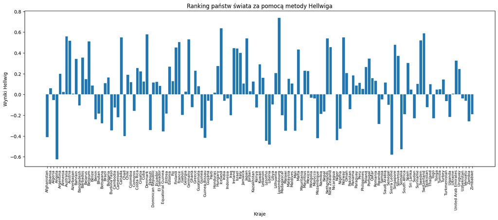

```python
import pandas as pd
import matplotlib.pyplot as plt

x_dane = dane['Countries']
y_dane = dane['Wyniki Hellwig']

fig = plt.figure(figsize=(18, 6))
ax = plt.axes()
plt.bar(x_dane, y_dane, align='center')

plt.xlabel('Kraje')
plt.ylabel('Wyniki Hellwig')
plt.title('Ranking państw świata za pomocą metody Hellwiga')
plt.xticks(rotation='vertical')
ax.tick_params(axis='x', labelsize=8)
plt.show()
```

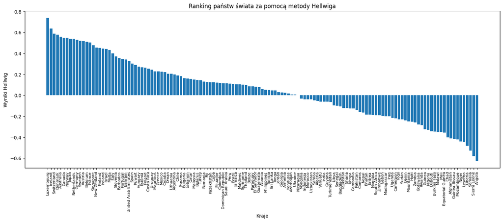

```python
import pandas as pd
import matplotlib.pyplot as plt

x_dane = dane_sorted['Countries']
y_dane = dane_sorted['Wyniki Hellwig']

fig = plt.figure(figsize=(18, 6))
ax = plt.axes()
plt.bar(x_dane, y_dane, align='center')

plt.xlabel('Kraje')
plt.ylabel('Wyniki Hellwig')
plt.title('Ranking państw świata za pomocą metody Hellwiga')
plt.xticks(rotation='vertical')
ax.tick_params(axis='x', labelsize=8)
plt.show()
```

# Wyniki

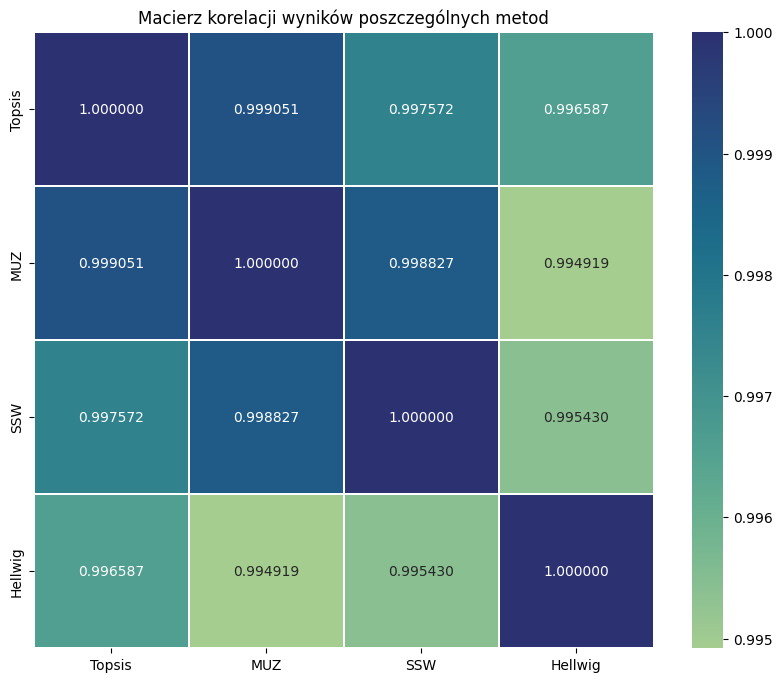

```python
import pandas as pd
import numpy as np
import matplotlib.pyplot as plt
import seaborn as sns

wyniki=topsis_df.copy()
wyniki= wyniki.merge(muz_df, on='Countries', how='outer').merge(ssw_df, on='Countries', how='outer').merge(hellwig_df, on='Countries', how='outer')

max_minus_min = []
srednia = []
for i in range(len(wyniki)):
  values = [wyniki.loc[i, 'Topsis'], wyniki.loc[i, 'MUZ'], wyniki.loc[i, 'SSW'], wyniki.loc[i, 'Hellwig']]

  najm = min(values)
  najw = max(values)

  srednia.append(np.mean(values))

  max_minus_min.append(najw - najm)

wyniki['max - min'] = max_minus_min
wyniki['Średnia'] = srednia

korelacja=wyniki.drop(columns=['Countries', 'max - min', 'Średnia']).corr()
plt.figure(figsize = (10, 8))
sns.heatmap(korelacja, cmap="crest", annot=True, linewidths=1.25, cbar=True, fmt='.6f').set(title="Macierz korelacji wyników poszczególnych metod")
plt.show()
```

```python
display(wyniki.sort_values(by='Średnia', ascending=True))
```

|  | Countries | Topsis | MUZ | SSW | Hellwig | max - min | Średnia |
| --- | --- | --- | --- | --- | --- | --- | --- |
| 0 | Luxembourg | 1 | 1 | 1 | 1 | 0 | 1.00 |
| 1 | Iceland | 2 | 2 | 2 | 2 | 0 | 2.00 |
| 2 | Switzerland | 3 | 4 | 4 | 3 | 1 | 3.50 |
| 3 | Denmark | 4 | 3 | 3 | 4 | 1 | 3.50 |
| 4 | Australia | 5 | 6 | 6 | 5 | 1 | 5.50 |
| 6 | Sweden | 7 | 5 | 5 | 11 | 6 | 7.00 |
| 5 | Canada | 6 | 8 | 10 | 6 | 4 | 7.50 |
| 7 | Germany | 8 | 7 | 7 | 10 | 3 | 8.00 |
| 10 | Japan | 11 | 9 | 8 | 8 | 3 | 9.00 |
| 8 | Norway | 9 | 10 | 11 | 7 | 4 | 9.25 |
| 9 | Netherlands | 10 | 11 | 9 | 9 | 2 | 9.75 |
| 11 | France | 12 | 12 | 12 | 14 | 2 | 12.50 |
| 12 | Austria | 13 | 14 | 15 | 12 | 3 | 13.50 |
| 13 | Belgium | 14 | 15 | 14 | 13 | 2 | 14.00 |
| 14 | Singapore | 15 | 13 | 13 | 15 | 2 | 14.00 |
| 15 | New Zealand | 16 | 16 | 16 | 16 | 0 | 16.00 |
| 17 | Israel | 18 | 18 | 18 | 19 | 1 | 18.25 |
| 18 | Malta | 19 | 17 | 17 | 20 | 3 | 18.25 |
| 16 | Ireland | 17 | 19 | 20 | 18 | 3 | 18.50 |
| 19 | Finland | 20 | 20 | 19 | 17 | 3 | 19.00 |
| 20 | Slovenia | 21 | 21 | 21 | 22 | 1 | 21.25 |
| 21 | Italy | 22 | 25 | 24 | 21 | 4 | 23.00 |
| 22 | Barbados | 23 | 23 | 23 | 23 | 0 | 23.00 |
| 24 | Bahrain | 25 | 22 | 22 | 25 | 3 | 23.50 |
| 23 | United Arab Emirates | 24 | 24 | 25 | 26 | 2 | 24.75 |
| 25 | Portugal | 26 | 28 | 27 | 24 | 4 | 26.25 |
| 27 | Kuwait | 28 | 26 | 26 | 28 | 2 | 27.00 |
| 26 | Spain | 27 | 27 | 28 | 27 | 1 | 27.25 |
| 28 | Estonia | 29 | 29 | 30 | 30 | 1 | 29.50 |
| 30 | Costa Rica | 31 | 31 | 29 | 32 | 3 | 30.75 |

[output cut: 103 more lines]

## Wnioski na podstawie wyników

Na podstawie podanej macierzy korelacji można stwierdzić, że wszystkie metody rankingu liniowego są bardzo silnie skorelowane między sobą. Wszystkie wartości korelacji są bardzo bliskie 1 dla każdej pary metod, co sugeruje, że wyniki uzyskane przez te metody są praktycznie identyczne lub bardzo zbliżone.

Jeśli chodzi o najbardziej podobne metody, można zauważyć, że metody Topsis i MUZ mają najwyższą korelację, wynoszącą około 0.999.

Wyniki najbardziej odstające od innych metod generuje metoda Hellwiga na przykład dla państw takich jak: Qatar, Mauritius, Cuba, Turkey metoda Hellwiga wstawia dane państwo nawet o 10 miejsc w dół, albo w górę w rankingu w porównaniu do innych metod.

# Podsumowanie

W naszej pracy przy użyciu powyższych metod i wybranych danych, państwami z największą "jakością życia" są Luksemburg, Islandia oraz Szwajcaria natomiast państwa, które wypadły najgorzej w rankingu to Angola, Sierra Leone oraz Somalia.

Należy jednak zwrócić uwagę na fakt, że wyniki rankingu mogą znacząco różnić się w przypadku gdyby użyte zostały inne metody bądź inne zbiory danych (na przykład z innego roku, bądź po prostu korzystające z innych cech badanych). Wtedy rozkład państw w rankingu mógłby być znacząco inny niż powstały w naszym badaniu.

Aby badania lepiej odzwierciedlały rzeczywistość należałoby dodać więcej cech z wiarygodnych źródeł danych, powtórzyć badanie dla danych z innych lat w celu znalezienia lepszej korelacji w stosunku do rozwoju państwa lub różnych wydarzeń (na przykład wojen, klęsk żywiołowych, zmian politycznych, klimatycznych, gospodarczych), które mogą jak wiadomo znacząco wpłynąć na "jakość życia" w danym państwie dla przeciętnego mieszkańca.

> Wyniki badania wskazują, że wybór metody porządkowania linowego rzutuje na ranking badanych obiektów. Zastosowana procedura stanowi, pomocne narzędzie wyboru metody porządkowania liniowego obiektów (Problemy Rolnictwa Światowego tom 18 XXXIII, zeszyt 2, 2018: 183–192" autorstwa Karol Kukuła, Lidia Luty)

# Bibliografia

Kukuła, Karol, i Lidia Luty. 2018. “O Wyborze Metody Porządkowania Liniowego Do Oceny Gospodarki Odpadami W Polsce W Ujęciu Przestrzennym.” Zeszyty Naukowe SGGW W Warszawie - Problemy Rolnictwa Światowego 18 (2): 183–92. https://doi.org/10.22630/prs.2018.18.2.46.

Sompolska-Rzeczuła, Agnieszka. 2020. “Zastosowanie liniowego porządkowania obiektów do oceny aktywności ekonomicznej ludności w ujęciu województw” Wiadomości Statystyczne. The Polish Statistician 65 (3): 46–61. https://doi.org/10.5604/01.3001.0014.0456.

Tzeng, Gwo-Hshiung, i Jih-Jeng Huang. 2011. “Multiple Attribute Decision Making,” June. https://doi.org/10.1201/b11032.

Hwang, C.L., Yoon, K. 1981. Multiple Attribute Decision Making. Methods and Applications A State-of-the-Art Survey. New York: Springer-Verlag Berlin Heidelberg.

Kędzior, Z. 2003. Metodologiczne aspekty badania jakości życia

Ostasiewicz, W. 2004. Ocena i analiza jakości życia. Wrocław: Wydawnictwo AE

Panek, T. 2009. Statystyczne metody wielowymiarowej analizy porównawczej. Warszawa: Wydawnictwo SGH – Oficyna Wydawnicza.

Yoon, K., Hwang, C.L. 1995. Multiple Attribute Decision Making: An Introduction. California: Sage Publications, Thousand Oaks.

Borys T., 1978, Metody normowania cech w statystycznych badaniach porównawczych, Przegląd Statystyczny, 25 (2), 227–239.

Bartosiewicz S., 1976, Propozycja metody tworzenia zmiennych syntetycznych, Zeszyty Naukowe AE, 84, Wrocław, 5–7.

Kukuła K., Luty L., (2015a), Propozycja procedury wspomagającej wybór metody porządkowania liniowego, Przegląd Statystyczny, 62 (2), 219–231.

## Inne

Dane zostały zebrane z kilku źródeł, natomiast wszystkie dotyczą tych samych państw i tego samego roku (2017).

**Access to electricity, Internet Usage** (`sustainability.csv`):

https://www.kaggle.com/datasets/hn4ever/world-development-indicators-by-countries

Dane z WorldBank (na licencji [CC BY 4.0 Deed](https://creativecommons.org/licenses/by/4.0/deed.pl))

**Unemployment rate**:

https://data.worldbank.org/indicator/SL.UEM.TOTL.ZS?end=2022&name_desc=false&start=1991&view=chart

Licencja [CC BY 4.0 Deed](https://creativecommons.org/licenses/by/4.0/deed.pl)

**Infant Mortality per 1000 births, GDP per capita, Literacy, Phones per 1000 people, Deathrate, Service**

https://www.kaggle.com/datasets/fernandol/countries-of-the-world/

Licencja [CC0 1.0 Deed](https://creativecommons.org/publicdomain/zero/1.0/)

**Life Expectancy**

https://www.kaggle.com/datasets/amirhosseinmirzaie/countries-life-expectancy

Licencja [Community Data License Agreement – Sharing, Version 1.0](https://cdla.dev/sharing-1-0/)